# HELPmiss (Data Verbs) Activity

Hejing Cui

## Set Up:

```r
rm(list = ls())     # clean up your R environment

# load packages
library(tidyverse)  # includes lots of data verbs like `group_by()` and `summarise()`
library(mosaicData) # includes the `HELPmiss` data set
library(dplyr)
library(ggplot2)

# Load the `HELPmiss` data set into our RStudio environment
data("HELPmiss", package = "mosaicData")
```

## Helpful links:

- Look though the DC Textbook for `tidyverse` functions.
- Check out some of these RStudio cheat sheets:
  - https://www.rstudio.com/wp-content/uploads/2015/02/data-wrangling-cheatsheet.pdf
  - https://www.rstudio.com/resources/cheatsheets/
  - https://s3.amazonaws.com/assets.datacamp.com/blog_assets/Tidyverse+Cheat+Sheet.pdf

## Task 1: Data Description

*Write several sentences (or a bullet list) describing the HELP Study and the resulting `HELPmiss` data. Your description should investigate basic data provenance (e.g., Who, What, When, Where, Why, How), explain the setting for the data, specify what each case represents in the data, and remark on inclusion/exclusion criteria.*

- investigate by searching R help documentation
- there’s a research paper cited where additional detail is provided
- The HELP study was a clinical trial on adult inpatients recruited from detoxification unit. The end goal is assigning patients to corresponding primary medical care. For each record, there is a treat variable indicating whether the patient was randomized to HELP clinic.
- Patients in the study are all adults who spoke Spanish or English and have alcohol, heroin or cocaine history.
- This dataset is a subset of HELPfull data, including 5 timepoints and additional variables

## Task 2: Basic Summaries

*Produce one or more R expressions involving `summarize()` and `HELPmiss` to address each of the following prompts.*

1. number of people (cases) in `HELPmiss` study

```r
#Your code here
row_count <- HELPmiss %>% summarize(count = n())
print(paste("number of people in study: ", row_count))
```

```
[1] "number of people in study:  470"
```

2. total number of times in the past 6 months entered a detox program (measured at baseline) for all the people in `HELPmiss`.

```r
#Your code here
# need to remove na otherwise the result will be na
data <- HELPmiss %>% summarize(total = sum(e2b, na.rm = TRUE))
data$total
```

```
[1] 549
```

3. mean time (in days) to first use of any substance post-detox for all the people in `HELPmiss`

```r
#Your code here
data <- HELPmiss %>% summarize(avg = mean(daysanysub, na.rm = TRUE))
data$avg
```

```
[1] 75.13095
```

## Task 3: Group Summaries

*Repeat task 2 above, but add code chunks to calculate result group-by-group according to each prompt (i.e. each promt should have three statements for each of the three prompts in task 2). Be sure to show all R code and write a sentence or two about what you observe in the results. Remember, you can add multiple statistics inside `summary`.*

- males versus females
- homeless or not
- substance
- break down the homeless versus housed further, by sex
- homeless versus housed broken down by substance

### males versus females

```r
#Your code here
# 1. number of people (cases) in HELPmiss study
HELPmiss %>% group_by(sex) %>% summarize(num_of_people = n())
```

| sex | num_of_people |
| --- | --- |
| male | 359 |
| female | 111 |

```r
# I observed that most patients are male
# male is around 3/4 of total patients population.

# 2. total number of times in the past 6 months entered a detox program (measured at baseline) for all the people in HELPmiss
HELPmiss %>% group_by(sex) %>% summarize(total = sum(e2b, na.rm = TRUE))
```

| sex | total |
| --- | --- |
| male | 457 |
| female | 92 |

```r
# I observed that male are much more likely to enter a detox program comparing with female

# 3. mean time (in days) to first use of any substance post-detox for all the people in HELPmiss
HELPmiss %>% group_by(sex) %>% summarize(avg = mean(daysanysub, na.rm = TRUE))
```

| sex | avg |
| --- | --- |
| male | 72.60513 |
| female | 83.77193 |

```r
# female on average takes longer in terms of first use of substance post-detox
```

### homeless or not

```r
#Your code here
# 1. number of people (cases) in HELPmiss study
HELPmiss %>% group_by(homeless) %>% summarize(num_of_people = n())
```

| homeless | num_of_people |
| --- | --- |
| housed | 251 |
| homeless | 219 |

```r
# I observed that the distribution on homeless and not homeless are pretty close

# 2. total number of times in the past 6 months entered a detox program (measured at baseline) for all the people in HELPmiss
HELPmiss %>% group_by(homeless) %>% summarize(total = sum(e2b, na.rm = TRUE))
```

| homeless | total |
| --- | --- |
| housed | 160 |
| homeless | 389 |

```r
# I observed that homeless are much more likely to enter a detox program comparing with housed

# 3. mean time (in days) to first use of any substance post-detox for all the people in HELPmiss
HELPmiss %>% group_by(homeless) %>% summarize(avg = mean(daysanysub, na.rm = TRUE))
```

| homeless | avg |
| --- | --- |
| housed | 77.10078 |
| homeless | 73.06504 |

```r
# housed on average takes longer in terms of first use of substance post-detox but the number is pretty close to homeless
```

### substance

```r
#Your code here
# 1. number of people (cases) in HELPmiss study
HELPmiss %>% group_by(substance) %>% summarize(num_of_people = n())
```

| substance | num_of_people |
| --- | --- |
| alcohol | 185 |
| cocaine | 156 |
| heroin | 128 |
| missing | 1 |

```r
# I observed that the most patients have alcohol history, then cocaine, then heroin

# 2. total number of times in the past 6 months entered a detox program (measured at baseline) for all the people in HELPmiss
HELPmiss %>% group_by(substance) %>% summarize(total = sum(e2b, na.rm = TRUE))
```

| substance | total |
| --- | --- |
| alcohol | 242 |
| cocaine | 98 |
| heroin | 208 |
| missing | 1 |

```r
# I observed that alcohol and heroin patients are much more likely to enter a detox program in past 6 months

# 3. mean time (in days) to first use of any substance post-detox for all the people in HELPmiss
HELPmiss %>% group_by(substance) %>% summarize(avg = mean(daysanysub, na.rm = TRUE))
```

| substance | avg |
| --- | --- |
| alcohol | 78.49495 |
| cocaine | 86.67033 |
| heroin | 52.82258 |
| missing | NaN |

```r
# patients have cocaine history on average takes longer in terms of first use of substance post-detox but the number is pretty close to alcohol
```

### homeless versus housed broken down by sex

```r
#Your code here
# 1. number of people (cases) in HELPmiss study
HELPmiss %>% group_by(homeless, sex) %>% summarize(num_of_people = n())
```

| homeless | sex | num_of_people |
| --- | --- | --- |
| housed | male | 182 |
| housed | female | 69 |
| homeless | male | 177 |
| homeless | female | 42 |

```r
# Gender distribution appears to be the same with task 1. In both housed and homeless, there are more male patients comparing with female

# 2. total number of times in the past 6 months entered a detox program (measured at baseline) for all the people in HELPmiss
HELPmiss %>% group_by(homeless, sex) %>% summarize(total = sum(e2b, na.rm = TRUE))
```

| homeless | sex | total |
| --- | --- | --- |
| housed | male | 110 |
| housed | female | 50 |
| homeless | male | 347 |
| homeless | female | 42 |

```r
# In both homeless and housed group, male are more likely to enter a detox program in past 6 months.

# 3. mean time (in days) to first use of any substance post-detox for all the people in HELPmiss
HELPmiss %>% group_by(homeless, sex) %>% summarize(avg = mean(daysanysub, na.rm = TRUE))
```

| homeless | sex | avg |
| --- | --- | --- |
| housed | male | 74.30851 |
| housed | female | 84.60000 |
| homeless | male | 71.01980 |
| homeless | female | 82.45455 |

```r
# in both housed and homeless groups, female on average has longer time duration on first use of any substance.
```

### homeless versus housed broken down by substance

```r
#Your code here
# 1. number of people (cases) in HELPmiss study
HELPmiss %>% group_by(homeless, substance) %>% summarize(num_of_people = n())
```

| homeless | substance | num_of_people |
| --- | --- | --- |
| housed | alcohol | 76 |
| housed | cocaine | 96 |
| housed | heroin | 79 |
| homeless | alcohol | 109 |
| homeless | cocaine | 60 |
| homeless | heroin | 49 |
| homeless | missing | 1 |

```r
# In housed group, there are more patients with cocaine history comparing with other two substance while in homeless group, there are more patients with alcohol history.

# 2. total number of times in the past 6 months entered a detox program (measured at baseline) for all the people in HELPmiss
HELPmiss %>% group_by(homeless, substance) %>% summarize(total = sum(e2b, na.rm = TRUE))
```

| homeless | substance | total |
| --- | --- | --- |
| housed | alcohol | 34 |
| housed | cocaine | 37 |
| housed | heroin | 89 |
| homeless | alcohol | 208 |
| homeless | cocaine | 61 |
| homeless | heroin | 119 |
| homeless | missing | 1 |

```r
# We see a large number of homeless patients with alcohol and heroin history entered a detox program in past 6 months comparing with those in housed group

# 3. mean time (in days) to first use of any substance post-detox for all the people in HELPmiss
HELPmiss %>% group_by(homeless, substance) %>% summarize(avg = mean(daysanysub, na.rm = TRUE))
```

| homeless | substance | avg |
| --- | --- | --- |
| housed | alcohol | 104.79487 |
| housed | cocaine | 81.05556 |
| housed | heroin | 41.16667 |
| homeless | alcohol | 61.40000 |
| homeless | cocaine | 94.86486 |
| homeless | heroin | 68.96154 |
| homeless | missing | NaN |

```r
# In housed group, patients with alcohol history spent the longest time for first use of substance on average. In homeless group, that is patients with cocaine history.
```

## Task 4: Data Visualization & Observations

*Include one or more interesting plots from this data set involving at least 3 variables per plot. Write a few sentences to explain the story that your plot tells about these data. You can expand on the relationships that you studied in Task 2, or you can explore a different group of variables in `HELPmiss` that show something interesting. Remember to use the interactive commands in the console, generate the R commands that will reproduce your plot, and then paste the R commands into an R chunk in the RMarkdown file.*

*Remember, you can use* `esquisser` *or* `mplot` *in your console. But only include the ggplot code in this Rmd document.*

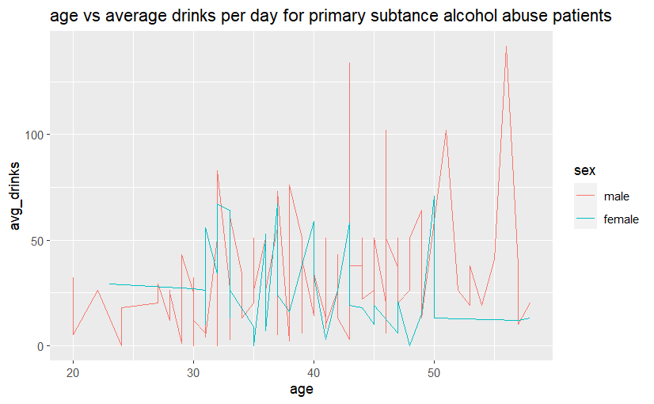

```r
# Your Code here.
data = subset(HELPmiss, substance=="alcohol")
ggplot(data=data, aes(x=age, y=avg_drinks, color=sex)) + geom_line() + ggtitle("age vs average drinks per day for primary subtance alcohol abuse patients")
```

I assumed that for patients whose primary substance abuse is alcohol, the average number of drinks per day should grow with their age. However, I found that the avg drinks is not correlated with age. But when looking at the plot grouped by sex, I’ve found that male on average consumes a lot more drinks per day comparing with female. The difference got amplified as age goes up.